# SF circ data – explore

John Little

2019-07-11

## Load Library Packages

```r
library(tidyverse)
library(skimr)
library(fs)
```

## Data Data

Data are ILS data on Library Usage from the City of San Francisco

- https://catalog.data.gov/dataset/library-usage
- https://data.sfgov.org/Culture-and-Recreation/Library

### Get Data

This is a large file (36.4 MB) from data.sfgov.org. It’s not super simple to upload it to GitHub but the code chunk below will download the file, and only if you don’t already have it.

```r
dir_create("data")

if (!file_exists("data/Library_Usage.csv")) {
  download.file("https://data.sfgov.org/api/views/qzz6-2jup/rows.csv?accessType=DOWNLOAD",
                destfile = "data/Library_Usage.csv")
}
```

### Import Data

Import the data and have a glimpse at the data types.

```r
circ_sf <- read_csv("data/Library_Usage.csv")
glimpse(circ_sf)
```

```
Observations: 423,448
Variables: 23
$ `Patron Type Code`             <dbl> 0, 0, 0, 0, 0, 0, 3, 0, 0, 0, 0, 0, 0, 0, 0, 0, 0, 0, 0, 4, 0,...
$ `Patron Type Definition`       <chr> "ADULT", "ADULT", "ADULT", "ADULT", "ADULT", "ADULT", "SENIOR"...
$ `Total Checkouts`              <dbl> 1092, 0, 31, 0, 0, 126, 0, 3002, 4, 20, 3, 102, 0, 45, 88, 22,...
$ `Total Renewals`               <dbl> 761, 0, 22, 0, 0, 11, 0, 1689, 0, 0, 1, 31, 0, 11, 64, 6, 0, 0...
$ `Age Range`                    <chr> "60 to 64 years", "20 to 24 years", "25 to 34 years", "45 to 5...
$ `Home Library Code`            <chr> "M6", "P1", "S7", "P1", "X", "M2", "C2", "P5", "C2", "S7", "A5...
$ `Home Library Definition`      <chr> "Mission", "Park", "Sunset", "Park", "Main Library", "Marina",...
$ `Circulation Active Month`     <chr> "July", "None", "April", "None", "None", "January", "None", "J...
$ `Circulation Active Year`      <chr> "2016", "None", "2016", "None", "None", "2016", "None", "2016"...
$ `Notice Preference Code`       <chr> "p", "z", "z", "a", "z", "z", "z", "p", "p", "z", "z", "z", "z...
$ `Notice Preference Definition` <chr> "phone", "email", "email", "print", "email", "email", "email",...
$ `Provided Email Address`       <lgl> FALSE, TRUE, TRUE, FALSE, TRUE, TRUE, TRUE, TRUE, TRUE, TRUE, ...
$ `Year Patron Registered`       <dbl> 2003, 2014, 2010, 2016, 2015, 2003, 2015, 2004, 2014, 2011, 20...
$ `Outside of County`            <lgl> FALSE, FALSE, FALSE, TRUE, FALSE, FALSE, TRUE, FALSE, FALSE, F...
$ `Supervisor District`          <dbl> 9, 5, 4, NA, 3, 2, NA, 9, 5, 7, NA, 9, NA, 4, 1, 2, NA, 7, 1, ...
$ `Location (address)`           <lgl> NA, NA, NA, NA, NA, NA, NA, NA, NA, NA, NA, NA, NA, NA, NA, NA...
$ `Location (city)`              <lgl> NA, NA, NA, NA, NA, NA, NA, NA, NA, NA, NA, NA, NA, NA, NA, NA...
$ `Location (state)`             <lgl> NA, NA, NA, NA, NA, NA, NA, NA, NA, NA, NA, NA, NA, NA, NA, NA...
$ `Location (zip)`               <lgl> NA, NA, NA, NA, NA, NA, NA, NA, NA, NA, NA, NA, NA, NA, NA, NA...
$ `SF Find Neighborhoods`        <lgl> NA, NA, NA, NA, NA, NA, NA, NA, NA, NA, NA, NA, NA, NA, NA, NA...
$ `Current Police Districts`     <lgl> NA, NA, NA, NA, NA, NA, NA, NA, NA, NA, NA, NA, NA, NA, NA, NA...
$ `Current Supervisor Districts` <lgl> NA, NA, NA, NA, NA, NA, NA, NA, NA, NA, NA, NA, NA, NA, NA, NA...
$ `Analysis Neighborhoods`       <lgl> NA, NA, NA, NA, NA, NA, NA, NA, NA, NA, NA, NA, NA, NA, NA, NA...
```

### Skim Data

Have a quick look, with skimmr, of the various data variables. What are the data types, what ranges of data fill out each variable.

```r
skim(circ_sf)
```

```
Skim summary statistics
 n obs: 423448
 n variables: 23

-- Variable type:character -----------------------------------------------------
                     variable missing complete      n min max empty n_unique
                    Age Range     215   423233 423448  12  17     0       10
     Circulation Active Month       0   423448 423448   3   9     0       13
      Circulation Active Year       0   423448 423448   4   4     0       15
            Home Library Code      40   423408 423448   1   5     0       79
      Home Library Definition       0   423448 423448   4  34     0       35
       Notice Preference Code       0   423448 423448   1   1     0        4
 Notice Preference Definition       0   423448 423448   4   5     0        4
       Patron Type Definition       0   423448 423448   5  19     0       18

-- Variable type:logical -------------------------------------------------------
                     variable missing complete      n   mean                          count
       Analysis Neighborhoods  423448        0 423448 NaN                            423448
     Current Police Districts  423448        0 423448 NaN                            423448
 Current Supervisor Districts  423448        0 423448 NaN                            423448
           Location (address)  423448        0 423448 NaN                            423448
              Location (city)  423448        0 423448 NaN                            423448
             Location (state)  423448        0 423448 NaN                            423448
               Location (zip)  423448        0 423448 NaN                            423448
            Outside of County       0   423448 423448   0.15 FAL: 359628, TRU: 63820, NA: 0
       Provided Email Address       0   423448 423448   0.79 TRU: 336420, FAL: 87028, NA: 0
        SF Find Neighborhoods  423448        0 423448 NaN                            423448

-- Variable type:numeric -------------------------------------------------------
               variable missing complete      n    mean     sd   p0  p25  p50  p75  p100     hist
       Patron Type Code       0   423448 423448    1.04   4.19    0    0    0    1   104 ▇▁▁▁▁▁▁▁
    Supervisor District  110310   313138 423448    6.29   3.12    1    4    6    9    11 ▆▃▅▇▃▃▅▇
        Total Checkouts       0   423448 423448  161.98 453.7     0    2   19  113 35907 ▇▁▁▁▁▁▁▁
         Total Renewals       0   423448 423448   59.66 225.01    0    0    2   27  8965 ▇▁▁▁▁▁▁▁
 Year Patron Registered       0   423448 423448 2010.35   4.36 2003 2007 2012 2014  2016 ▆▂▁▃▅▃▇▆
```

It looks like several fields are empty. Let’s drop them and then have another skim into the data. It’s the same data without a bunch of empty fields.

```r
circ_sf <- circ_sf %>%
  select(- `Analysis Neighborhoods`, -`Current Police Districts`,
         -`Current Supervisor Districts`, -`Location (city)`,
         -`Location (state)`, -`Location (zip)`,
         -`SF Find Neighborhoods`)

skim(circ_sf)
```

```
Skim summary statistics
 n obs: 423448
 n variables: 16

-- Variable type:character -----------------------------------------------------
                     variable missing complete      n min max empty n_unique
                    Age Range     215   423233 423448  12  17     0       10
     Circulation Active Month       0   423448 423448   3   9     0       13
      Circulation Active Year       0   423448 423448   4   4     0       15
            Home Library Code      40   423408 423448   1   5     0       79
      Home Library Definition       0   423448 423448   4  34     0       35
       Notice Preference Code       0   423448 423448   1   1     0        4
 Notice Preference Definition       0   423448 423448   4   5     0        4
       Patron Type Definition       0   423448 423448   5  19     0       18

-- Variable type:logical -------------------------------------------------------
               variable missing complete      n   mean                          count
     Location (address)  423448        0 423448 NaN                            423448
      Outside of County       0   423448 423448   0.15 FAL: 359628, TRU: 63820, NA: 0
 Provided Email Address       0   423448 423448   0.79 TRU: 336420, FAL: 87028, NA: 0

-- Variable type:numeric -------------------------------------------------------
               variable missing complete      n    mean     sd   p0  p25  p50  p75  p100     hist
       Patron Type Code       0   423448 423448    1.04   4.19    0    0    0    1   104 ▇▁▁▁▁▁▁▁
    Supervisor District  110310   313138 423448    6.29   3.12    1    4    6    9    11 ▆▃▅▇▃▃▅▇
        Total Checkouts       0   423448 423448  161.98 453.7     0    2   19  113 35907 ▇▁▁▁▁▁▁▁
         Total Renewals       0   423448 423448   59.66 225.01    0    0    2   27  8965 ▇▁▁▁▁▁▁▁
 Year Patron Registered       0   423448 423448 2010.35   4.36 2003 2007 2012 2014  2016 ▆▂▁▃▅▃▇▆
```

What is Circulation Year Active?

I didn’t find the codebook very useful (not uncommon.) But if I have a closer look at home many observations (rows) of each year (year as a category) maybe I can figure out this variable.

```r
fct_count(circ_sf$`Circulation Active Year`, sort = TRUE)
```

| f | n |
| --- | --- |
| 2016 | 147901 |
| 2015 | 79623 |
| None | 67904 |
| 2014 | 63502 |
| 2013 | 43722 |
| 2012 | 9571 |
| 2011 | 3108 |
| 2010 | 2975 |
| 2009 | 1820 |
| 2008 | 1244 |

[output cut: 5 more lines]

What is Total Checkouts?

At this point, I’m still a little stumped on the `Circulation Active Year` variable but I’ll press on. Let’s have a look at the `Total Checkouts` variable. It looks like the median and mean functions tell me a little more about how skewed this variable is.

```r
circ_sf %>%
  filter(`Circulation Active Year` != "None") %>%
  count(`Total Checkouts`, sort = TRUE)
```

| Total Checkouts | n |
| --- | --- |
| 1 | 23478 |
| 2 | 15917 |
| 3 | 12922 |
| 4 | 10697 |
| 5 | 9326 |
| 6 | 8075 |
| 7 | 7125 |
| 8 | 6521 |
| 9 | 5817 |
| 0 | 5692 |

[output cut: 990 more lines]

```r
circ_sf %>%
  filter(`Circulation Active Year` != "None") %>%
  summarise(mean(`Total Checkouts`), median(`Total Checkouts`))
```

| mean(`Total Checkouts`) | median(`Total Checkouts`) |
| --- | --- |
| 192.9182 | 34 |

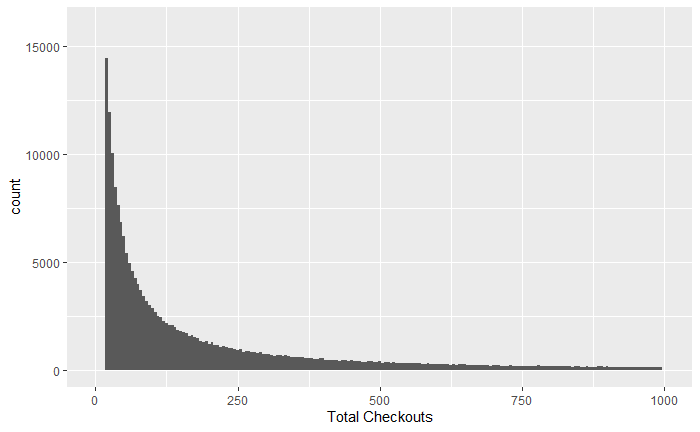

```r
circ_sf %>%
  filter(`Circulation Active Year` != "None") %>%
  filter( `Circulation Active Year` <400) %>%
  ggplot(aes(`Total Checkouts`)) +
  geom_histogram(binwidth = 5) +
  xlim(0, 1000) +
  ylim(0, 16000)
```

O.K. I’m a little bored with those variables. What else can I learn. Maybe I can learn something about the distribution of the `Patron` status variable. Nothing too earth shattering here but at least it makes sense when I look at the data. O.K. the data aren’t completely wack.

```r
fct_count(circ_sf$`Patron Type Definition`, sort = TRUE)
```

| f | n |
| --- | --- |
| ADULT | 272251 |
| JUVENILE | 59208 |
| SENIOR | 41619 |
| YOUNG ADULT | 28816 |
| WELCOME | 14931 |
| TEACHER CARD | 1782 |
| DIGITAL ACCESS CARD | 1744 |
| SPECIAL | 977 |
| STAFF | 862 |
| VISITOR | 415 |

[output cut: 8 more lines]

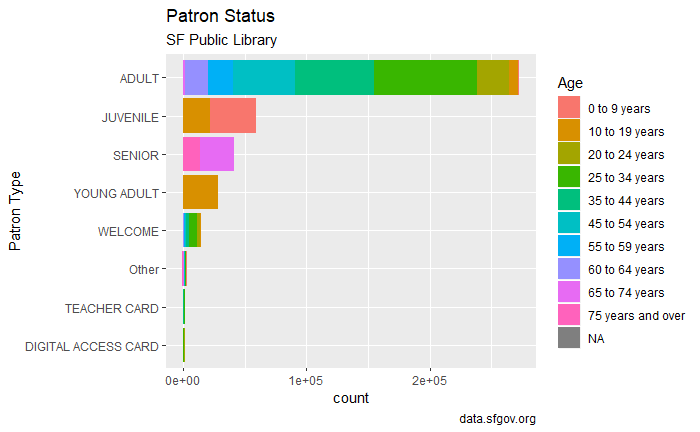

```r
ggplot(circ_sf, aes(fct_rev(fct_infreq(fct_lump(`Patron Type Definition`, prop = .003))),
                    fill = `Age Range`)) +
  geom_bar() +
  coord_flip() +
  labs(fill = "Age",
       x = "Patron Type",
       title = "Patron Status",
       subtitle = "SF Public Library",
       caption = "data.sfgov.org")
```

Time to investigate some more. I’ll have a different look at the `Circulation Active Year`. This is probably not the right graph. I’m most years the monthly subdivisions are abnormally symmetrical. Oh, an equal number of summarized monthly reports – probably. Well there is something weird going on in 2016. Also, what do I make of the year-by-year increase of total circulation?

```r
circ_sf2 <- circ_sf %>%
  mutate(circ_month = as_factor(`Circulation Active Month`)) %>%
  mutate(circ_month = fct_relevel(circ_month,
                                  levels =c("January", "February", "March",
                                            "April", "May", "June", "July",
                                            "August", "September", "October",
                                            "November", "December"))) %>%
  mutate(circ_month = na_if(circ_month, "None"))
```

```
Outer names are only allowed for unnamed scalar atomic inputs
```

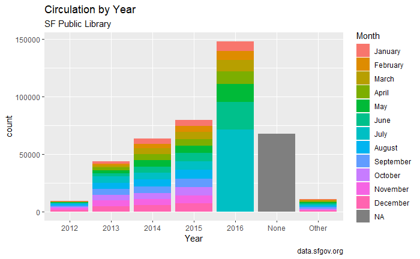

```r
ggplot(circ_sf2,
       aes(fct_lump(`Circulation Active Year`, n = 6),
                     fill = circ_month)) +
  geom_bar() +
  labs(title = "Circulation by Year",
       subtitle = "SF Public Library",
       x = "Year", fill = "Month",
       caption = "data.sfgov.org")
```

So, that bar graph is a little silly. I probably should have treated this like time-series data. Time for a line graph. Not my favorite graph but probably the right tool for the job. Let’s see. It looks like 2003 and 2016 are weird but otherwise a stead increase in total circulation. What? I wonder why they are tracking total circulation over time? I guess that’s interesting to someone. I could probably do some fancy math and get a monthly total by subtracting the previous total from the each monthly total. Wow. that feels like a lot of effort in data transformation. Wait, isn’t this just exploratory. O.K. that’s a good insight but I’ll put that off for the moment.

```
Factor `circ_month` contains implicit NA, consider using `forcats::fct_explicit_na`
```

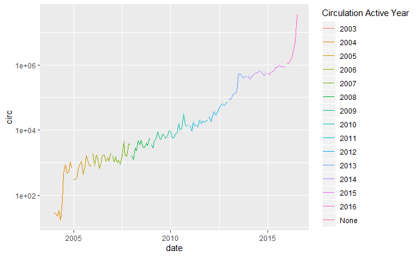

```r
circ_sf2 %>%
  group_by(`Circulation Active Year` , circ_month) %>%
  summarise(tot = round(sum(`Total Checkouts`))) %>%
  mutate(date =
           lubridate::parse_date_time(
             str_c(`Circulation Active Year`, `circ_month`, sep = "-"),
             "ym")) %>%
  gather("type", "circ", -date, -circ_month, -`Circulation Active Year`) %>%
  ggplot(aes(x = date)) +
    geom_line(aes(y = circ, color = `Circulation Active Year`)) +
    scale_y_log10()
```

So that line graph is cool but sometimes, when there are a lot of colors in the legend, it’s hard to perceive what is happening. You know what’s cool in ggplot? `facet_wrap` is cool. Below is a facet by year that make it much easier to see both steady progress and anomalies by year.

I forgot to explain why I’m taking a log of the y variable. Basically, the cumulative nature of the variable combined with the skewing in 2016 makes it hard to see the pattern without normalizing the scale of change. Logs are cool but they’re way easier to see than they are to explain.

```
Factor `circ_month` contains implicit NA, consider using `forcats::fct_explicit_na`
```

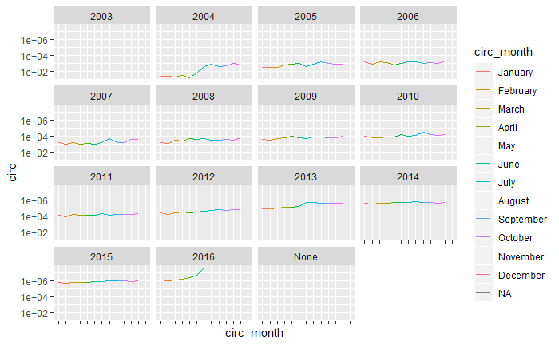

```r
circ_sf2 %>%
  group_by(`Circulation Active Year` , circ_month) %>%
  summarise(tot = round(sum(`Total Checkouts`))) %>%
  mutate(date =
           lubridate::parse_date_time(
             str_c(`Circulation Active Year`, `circ_month`, sep = "-"),
             "ym")) %>%
  gather("type", "circ", -date, -circ_month, -`Circulation Active Year`) %>%
  ggplot(aes(x = circ_month)) +
    geom_line(aes(y = circ, color = circ_month, group = 1)) +
    scale_y_log10() +
    scale_x_discrete(labels = NULL) +
    facet_wrap(~ `Circulation Active Year`)
```

O.K. As noted before, that total circ variable is a little weird. Mathematically, looking at totals can be misleading. Fortunately looking at the median **and** mean of the values does make it a bit easier to think about.

```
Factor `circ_month` contains implicit NA, consider using `forcats::fct_explicit_na`
```

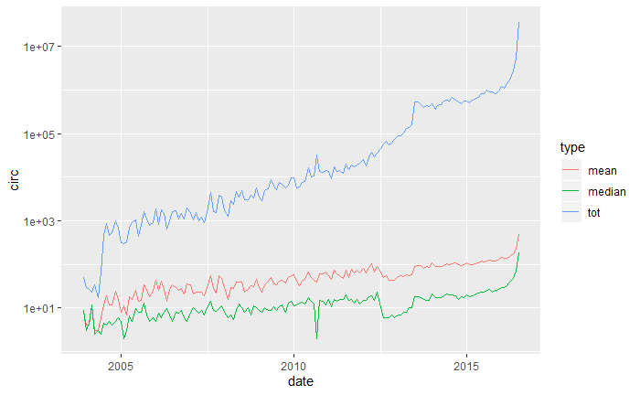

```r
circ_sf2 %>%
  group_by(`Circulation Active Year` , circ_month) %>%
  summarise(tot = round(sum(`Total Checkouts`)),
            mean = round(mean(`Total Checkouts`)),
            median = median(`Total Checkouts`)) %>%
  mutate(date =
           lubridate::parse_date_time(
             str_c(`Circulation Active Year`, `circ_month`, sep = "-"),
             "ym")) %>%
  gather("type", "circ", -date, -circ_month, -`Circulation Active Year`) %>%
  ggplot(aes(x = date)) +
    geom_line(aes(y = circ, color = type)) +
    scale_y_log10()
```

Alright. I still like facet_wrap. Let’s have a look at the above where each year is broken out.

```
Factor `circ_month` contains implicit NA, consider using `forcats::fct_explicit_na`
```

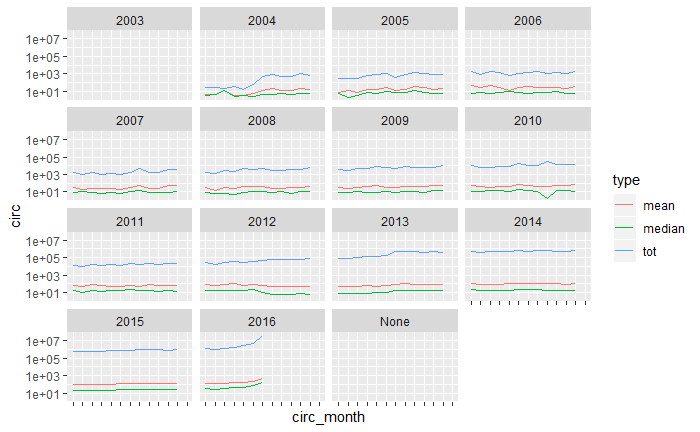

```r
circ_sf2 %>%
  group_by(`Circulation Active Year` , circ_month) %>%
  summarise(tot = round(sum(`Total Checkouts`)),
            mean = round(mean(`Total Checkouts`)),
            median = median(`Total Checkouts`)) %>%
  mutate(date =
           lubridate::parse_date_time(
             str_c(`Circulation Active Year`, `circ_month`, sep = "-"),
             "ym")) %>%
  gather("type", "circ", -date, -circ_month, -`Circulation Active Year`) %>%
  ggplot(aes(x = circ_month)) +
    geom_line(aes(y = circ, color = type, group = type)) +
    scale_y_log10() +
    scale_x_discrete(labels = NULL) +
    facet_wrap(~ `Circulation Active Year`)
```

I guess I’m probably gonna have to do some more math to get monthly totals that are not cumulative. Wow, this data is not as useful as I had hoped. Should I open a feature request with the ILS company? Or, would it be quicker and more empowering to learn how to make my own reports? This is not a trick question, the answer is actually pretty obvious.